# What Parking Tickets Mean for Toronto

Parking violations and parking tickets are a contentious topic for Torontonians. Drivers are subjected to misleading signs, police blitzes, and towings.

Toronto parking regulations have a reputation for being confusing and misleading. In this notebook we study parking tickets and to see what impact they have on the city and its citizens.

The data was obtained form the city of Toronto's Open Data catalogue and can be downloaded [here](https://www.toronto.ca/city-government/data-research-maps/open-data/open-data-catalogue/#75d14c24-3b7e-f344-4412-d8fd41f89455)

Align tables in markdown

```python
%%html
<style>
    table {
        margin-left: 0 !important
    }
    td, th {
        text-align: left !important
    }
</style>
```

## Data Dictionary

| Column | Meaning |
| --- | --- |
| TAG_NUMBER_MASKED | First three (3) characters masked with asterisks |
| DATE_OF_INFRACTION | Date the infraction occurred in YYYYMMDD format |
| INFRACTION_CODE | Applicable Infraction code (numeric) |
| INFRACTION_DESCRIPTION | Short description of the infraction |
| SET_FINE_AMOUNT | Amount of set fine applicable (in dollars) |
| TIME_OF_INFRACTION | Time the infraction occurred in HHMM format (24-hr clock) |
| LOCATION1 | Code to denote proximity (see table below) |
| LOCATION2 | Street address |
| LOCATION3 | Code to denote proximity (optional) |
| LOCATION4 | Street address (optional) |
| PROVINCE | Province or state code of vehicle licence plate |

```python
import pandas as pd
import numpy as np
import matplotlib.pyplot as plt
import seaborn as sns
```

The `parking_tags_2016.csv` file was created using csvkit's csvstack to combine four CSV files.

```python
tickets = pd.read_csv("data/parking_tickets_2016/parking_tags_2016.csv")
```

```python
tickets.info(memory_usage='deep')
```

```
<class 'pandas.core.frame.DataFrame'>
RangeIndex: 2254761 entries, 0 to 2254760
Data columns (total 12 columns):
origin                    int64
tag_number_masked         object
date_of_infraction        int64
infraction_code           float64
infraction_description    object
set_fine_amount           int64
time_of_infraction        float64
location1                 object
location2                 object
location3                 object
location4                 object
province                  object
dtypes: float64(2), int64(3), object(7)
memory usage: 959.6 MB
```

```python
tickets.head()
```

|  | origin | tag_number_masked | date_of_infraction | infraction_code | infraction_description | set_fine_amount | time_of_infraction | location1 | location2 | location3 | location4 | province |
| --- | --- | --- | --- | --- | --- | --- | --- | --- | --- | --- | --- | --- |
| 0 | 1 | ***03850 | 20160101 | 29.0 | PARK PROHIBITED TIME NO PERMIT | 30 | 0.0 | NR | 49 GLOUCESTER ST | NaN | NaN | ON |
| 1 | 1 | ***03851 | 20160101 | 29.0 | PARK PROHIBITED TIME NO PERMIT | 30 | 1.0 | NR | 45 GLOUCESTER ST | NaN | NaN | ON |
| 2 | 1 | ***98221 | 20160101 | 29.0 | PARK PROHIBITED TIME NO PERMIT | 30 | 2.0 | NR | 274 GEORGE ST | NaN | NaN | ON |
| 3 | 1 | ***85499 | 20160101 | 29.0 | PARK PROHIBITED TIME NO PERMIT | 30 | 2.0 | NR | 270 GEORGE ST | NaN | NaN | ON |
| 4 | 1 | ***03852 | 20160101 | 406.0 | PARK-VEH. W/O VALID ONT PLATE | 40 | 2.0 | NR | 45 GLOUCESTER ST | NaN | NaN | ON |

We can see that some of these columns could be converted to data types that represent them a little better and possibly reduce the memory being used.

```python
tickets.loc[ tickets['time_of_infraction'].isnull() == True]
```

|  | origin | tag_number_masked | date_of_infraction | infraction_code | infraction_description | set_fine_amount | time_of_infraction | location1 | location2 | location3 | location4 | province |
| --- | --- | --- | --- | --- | --- | --- | --- | --- | --- | --- | --- | --- |
| 6958 | 1 | ***95889 | 20160102 | 9.0 | STOP-SIGNED HWY-PROHIBIT TM/DY | 60 | NaN | N/S | GROSVENOR ST | W/O | BAY ST | ON |
| 6959 | 1 | ***65174 | 20160102 | 3.0 | PARK ON PRIVATE PROPERTY | 30 | NaN | NaN | 23 LASCELLES BLVD | NaN | NaN | ON |
| 11870 | 1 | ***13137 | 20160103 | 3.0 | PARK ON PRIVATE PROPERTY | 30 | NaN | NaN | 149 ICEBOAT TERRACE WAY | NaN | NaN | ON |
| 11871 | 1 | ***89885 | 20160103 | 9.0 | STOP-SIGNED HWY-PROHIBIT TM/DY | 60 | NaN | NR | 6 EMPRESS AVE | NaN | NaN | ON |
| 11872 | 1 | ***63273 | 20160103 | 3.0 | PARK ON PRIVATE PROPERTY | 30 | NaN | AT | 2460 WESTON RD | NaN | NaN | ON |
| 11873 | 1 | ***06014 | 20160103 | 3.0 | PARK ON PRIVATE PROPERTY | 30 | NaN | NaN | 91 AUGUSTA AVE | NaN | NaN | ON |
| 17887 | 1 | ***83554 | 20160104 | 9.0 | STOP-SIGNED HWY-PROHIBIT TM/DY | 60 | NaN | NaN | 195 GERRARD ST E | NaN | NaN | ON |
| 17888 | 1 | ***64703 | 20160104 | 3.0 | PARK ON PRIVATE PROPERTY | 30 | NaN | NaN | 3101 WESTON RD | NaN | NaN | ON |
| 17889 | 1 | ***64713 | 20160104 | 3.0 | PARK ON PRIVATE PROPERTY | 30 | NaN | NaN | 3101 WESTON RD | NaN | NaN | ON |
| 17890 | 1 | ***64716 | 20160104 | 3.0 | PARK ON PRIVATE PROPERTY | 30 | NaN | NaN | 3101 WESTON RD | NaN | NaN | ON |
| 24610 | 1 | ***61604 | 20160105 | 9.0 | STOP-SIGNED HWY-PROHIBIT TM/DY | 60 | NaN | O/F | 657 COLLEGE ST | NaN | NaN | ON |
| 24611 | 1 | ***27713 | 20160105 | 3.0 | PARK ON PRIVATE PROPERTY | 30 | NaN | NaN | 111 ELIZABETH STREET | NaN | NaN | ON |
| 24612 | 1 | ***95857 | 20160105 | 9.0 | STOP-SIGNED HWY-PROHIBIT TM/DY | 60 | NaN | N/R | 1289 PAPE AV | NaN | NaN | ON |
| 24613 | 1 | ***62128 | 20160105 | 403.0 | STOP-SIGNED HIGHWAY-RUSH HOUR | 150 | NaN | NaN | 620 CHURCH ST | NaN | NaN | ON |
| 24614 | 1 | ***62129 | 20160105 | 403.0 | STOP-SIGNED HIGHWAY-RUSH HOUR | 150 | NaN | NR | 82 ADELAIDE ST E | NaN | NaN | ON |
| 24615 | 1 | ***62130 | 20160105 | 403.0 | STOP-SIGNED HIGHWAY-RUSH HOUR | 150 | NaN | NaN | 82 ADELAIDE ST E | NaN | NaN | ON |
| 31548 | 1 | ***80864 | 20160106 | 3.0 | PARK ON PRIVATE PROPERTY | 30 | NaN | NaN | 2 BRAHMS AVE | NaN | NaN | ON |
| 31549 | 1 | ***15569 | 20160106 | 3.0 | PARK ON PRIVATE PROPERTY | 30 | NaN | NaN | 3561 EGLINTON AVE W | NaN | NaN | ON |
| 31550 | 1 | ***18456 | 20160106 | 312.0 | PARKING MACH-NOT USED/NO FEE | 30 | NaN | NaN | 3354 DUNDAS ST W | NaN | NaN | BC |
| 31551 | 1 | ***64980 | 20160106 | 3.0 | PARK ON PRIVATE PROPERTY | 30 | NaN | NaN | 30 FALSTAFF AVE | NaN | NaN | ON |
| 38575 | 1 | ***34821 | 20160107 | 3.0 | PARK ON PRIVATE PROPERTY | 30 | NaN | NaN | 2269 LAKESHORE BLVD W | NaN | NaN | ON |
| 38576 | 1 | ***78931 | 20160107 | 3.0 | PARK ON PRIVATE PROPERTY | 30 | NaN | NaN | 700 LAWRENCE AVE W | NaN | NaN | ON |
| 38577 | 1 | ***78934 | 20160107 | 3.0 | PARK ON PRIVATE PROPERTY | 30 | NaN | NaN | 700 LAWRENCE AVE W | NaN | NaN | ON |
| 38578 | 1 | ***30511 | 20160107 | 3.0 | PARK ON PRIVATE PROPERTY | 30 | NaN | NaN | 153 ISAAC DEVINS BLVD | NaN | NaN | ON |
| 38579 | 1 | ***40063 | 20160107 | 3.0 | PARK ON PRIVATE PROPERTY | 30 | NaN | AT | 200 QUEEN'S QUAY E | NaN | NaN | ON |
| 38580 | 1 | ***40064 | 20160107 | 3.0 | PARK ON PRIVATE PROPERTY | 30 | NaN | AT | 200 QUEEN'S QUAY E | NaN | NaN | ON |
| 38581 | 1 | ***53733 | 20160107 | 5.0 | PARK-SIGNED HWY-PROHIBIT DY/TM | 40 | NaN | NR | 478 KING ST W | NaN | NaN | ON |
| 38582 | 1 | ***62139 | 20160107 | 403.0 | STOP-SIGNED HIGHWAY-RUSH HOUR | 150 | NaN | NEAR | 26 WELLINGTON STREET E | NaN | NaN | ON |
| 45549 | 1 | ***10051 | 20160108 | 6.0 | PARK HWY OVER PERMITTED TIME | 0 | NaN | NaN | NaN | NaN | NaN | ON |
| 45550 | 1 | ***27714 | 20160108 | 3.0 | PARK ON PRIVATE PROPERTY | 30 | NaN | NaN | 111 ELIZABETH STREET | NaN | NaN | ON |
| ... | ... | ... | ... | ... | ... | ... | ... | ... | ... | ... | ... | ... |
| 2219720 | 3 | ***25727 | 20161222 | 3.0 | PARK ON PRIVATE PROPERTY | 30 | NaN | NaN | 205 HUMBER COLLEGE BLVD | NaN | NaN | ON |
| 2219721 | 3 | ***57743 | 20161222 | 3.0 | PARK ON PRIVATE PROPERTY | 30 | NaN | NaN | 3401 DUFFERIN ST | NaN | NaN | ON |
| 2219722 | 3 | ***27950 | 20161222 | 3.0 | PARK ON PRIVATE PROPERTY | 30 | NaN | NaN | DIXON RD | NaN | NaN | ON |
| 2219723 | 3 | ***93532 | 20161222 | 3.0 | PARK ON PRIVATE PROPERTY | 30 | NaN | NaN | NaN | NaN | NaN | ON |
| 2219724 | 3 | ***31998 | 20161222 | 312.0 | PARKING MACH-NOT USED/NO FEE | 30 | NaN | NaN | 31A PARLIAMENT ST | NaN | NaN | ON |
| 2225558 | 3 | ***40065 | 20161223 | 3.0 | PARK ON PRIVATE PROPERTY | 30 | NaN | AT | 308 GRANDRAVINE DR | NaN | NaN | ON |
| 2225559 | 3 | ***52001 | 20161223 | 3.0 | PARK ON PRIVATE PROPERTY | 30 | NaN | NaN | 190 EXBURY RD | NaN | NaN | ON |
| 2225560 | 3 | ***59925 | 20161223 | 347.0 | PARK IN A FIRE ROUTE | 250 | NaN | NaN | 1700 WILSON AVE | NaN | NaN | ON |
| 2225561 | 3 | ***06119 | 20161223 | 3.0 | PARK ON PRIVATE PROPERTY | 30 | NaN | NaN | 34 LEITH HILL RD | NaN | NaN | ON |
| 2225562 | 3 | ***18630 | 20161223 | 3.0 | PARK ON PRIVATE PROPERTY | 30 | NaN | NaN | 6429 FINCH AVE W | NaN | NaN | ON |
| 2225563 | 3 | ***24276 | 20161223 | 3.0 | PARK ON PRIVATE PROPERTY | 30 | NaN | NaN | 28 PLUM TREEWAY | NaN | NaN | ON |
| 2225564 | 3 | ***24278 | 20161223 | 3.0 | PARK ON PRIVATE PROPERTY | 30 | NaN | NaN | 2 MASCOT PLACE | NaN | NaN | ON |
| 2225565 | 3 | ***14392 | 20161223 | 3.0 | PARK ON PRIVATE PROPERTY | 30 | NaN | NaN | 2848 ELLESMERE RD | NaN | NaN | ON |
| 2228783 | 3 | ***48932 | 20161224 | 3.0 | PARK ON PRIVATE PROPERTY | 30 | NaN | NaN | 500 TRETHEWEY DR | NaN | NaN | ON |
| 2228784 | 3 | ***87544 | 20161224 | 312.0 | PARKING MACH-NOT USED/NO FEE | 30 | NaN | NaN | 11 KENWOOD AVE | NaN | NaN | ON |
| 2228785 | 3 | ***73461 | 20161224 | 3.0 | PARK ON PRIVATE PROPERTY | 30 | NaN | NaN | 20 EDGECLIFF GOLFWAY | NaN | NaN | ON |
| 2233564 | 3 | ***98490 | 20161227 | 3.0 | PARK ON PRIVATE PROPERTY | 30 | NaN | NaN | 19 EVA RD | NaN | NaN | ON |
| 2239935 | 3 | ***54295 | 20161228 | 3.0 | PARK ON PRIVATE PROPERTY | 30 | NaN | NaN | 3401 DUFFERIN ST | NaN | NaN | ON |
| 2239936 | 3 | ***17003 | 20161228 | 3.0 | PARK ON PRIVATE PROPERTY | 30 | NaN | NaN | 5230 DUNDAS ST W | NaN | NaN | ON |
| 2239937 | 3 | ***74597 | 20161228 | 3.0 | PARK ON PRIVATE PROPERTY | 30 | NaN | NaN | 900 QUEEN'S PLATE DR | NaN | NaN | ON |
| 2245368 | 3 | ***12457 | 20161229 | 29.0 | PARK PROHIBITED TIME NO PERMIT | 30 | NaN | AT | 2468 YONGE ST | NaN | NaN | ON |
| 2251423 | 4 | ***73242 | 20161230 | 3.0 | PARK ON PRIVATE PROPERTY | 30 | NaN | AT | 47 THORNCLIFE PK DR | NaN | NaN | ON |
| 2251424 | 4 | ***53397 | 20161230 | 3.0 | PARK ON PRIVATE PROPERTY | 30 | NaN | NaN | 20 TRUDELLE ST | NaN | NaN | PQ |
| 2251425 | 4 | ***19925 | 20161230 | 3.0 | PARK ON PRIVATE PROPERTY | 30 | NaN | AT | 2450 SHEPPARD AVE E | NaN | NaN | ON |
| 2251426 | 4 | ***67727 | 20161230 | 3.0 | PARK ON PRIVATE PROPERTY | 30 | NaN | NaN | 130 WIDDICOMBE HILL BLVD | NaN | NaN | ON |
| 2251427 | 4 | ***67729 | 20161230 | 3.0 | PARK ON PRIVATE PROPERTY | 30 | NaN | NaN | 130 WIDDICOMBE HILL BLVD | NaN | NaN | ON |
| 2251428 | 4 | ***76168 | 20161230 | 3.0 | PARK ON PRIVATE PROPERTY | 30 | NaN | NaN | 30 CHURCH ST | NaN | NaN | ON |
| 2251429 | 4 | ***76908 | 20161230 | 3.0 | PARK ON PRIVATE PROPERTY | 30 | NaN | NaN | 3401 DUFFERIN ST | NaN | NaN | ON |
| 2254759 | 4 | ***60163 | 20161231 | 3.0 | PARK ON PRIVATE PROPERTY | 30 | NaN | NaN | 3401 DUFFERIN ST | NaN | NaN | ON |
| 2254760 | 4 | ***67517 | 20161231 | 3.0 | PARK ON PRIVATE PROPERTY | 30 | NaN | NaN | 920 SHEPPARD AVE W | NaN | NaN | ON |

1329 rows × 12 columns

We can convert this column since the values are really four digits representing 24 hour time in the format HHMM. There are some null values so we'll ignore those for now.

```python
tickets['time_of_infraction'] = tickets['time_of_infraction'].astype('uint16', errors='ignore')
```

```python
tickets.loc[ tickets['infraction_code'].isnull() == True]
```

|  | origin | tag_number_masked | date_of_infraction | infraction_code | infraction_description | set_fine_amount | time_of_infraction | location1 | location2 | location3 | location4 | province |
| --- | --- | --- | --- | --- | --- | --- | --- | --- | --- | --- | --- | --- |
| 1629565 | 3 | ***38875 | 20160916 | NaN | PARK ON PRIVATE PROPERTY | 30 | 1042.0 | NaN | 2075 BAYVIEW AVE | NaN | NaN | ON |

We find that there's one ticket with no infraction code. We could replace it with 0 if 0 isn't an infraction code. We can check that below.

```python
tickets[tickets['infraction_code'] == 0]
```

|  | origin | tag_number_masked | date_of_infraction | infraction_code | infraction_description | set_fine_amount | time_of_infraction | location1 | location2 | location3 | location4 | province |
| --- | --- | --- | --- | --- | --- | --- | --- | --- | --- | --- | --- | --- |

```python
tickets.loc[1629565, 'infraction_code'] = 0
```

```python
tickets[tickets['infraction_code'] == 0]
```

|  | origin | tag_number_masked | date_of_infraction | infraction_code | infraction_description | set_fine_amount | time_of_infraction | location1 | location2 | location3 | location4 | province |
| --- | --- | --- | --- | --- | --- | --- | --- | --- | --- | --- | --- | --- |
| 1629565 | 3 | ***38875 | 20160916 | 0.0 | PARK ON PRIVATE PROPERTY | 30 | 1042.0 | NaN | 2075 BAYVIEW AVE | NaN | NaN | ON |

```python
tickets['infraction_code'] = tickets['infraction_code'].astype('uint16')
```

```python
tickets.info(memory_usage='deep')
```

```
<class 'pandas.core.frame.DataFrame'>
RangeIndex: 2254761 entries, 0 to 2254760
Data columns (total 12 columns):
origin                    int64
tag_number_masked         object
date_of_infraction        int64
infraction_code           uint16
infraction_description    object
set_fine_amount           int64
time_of_infraction        float64
location1                 object
location2                 object
location3                 object
location4                 object
province                  object
dtypes: float64(1), int64(3), object(7), uint16(1)
memory usage: 946.7 MB
```

We've managed to reduce memory usage by 13MB. We can convert more of our columns however. The origin column just tracks the spreadsheet number that the row belongs to. It was created when we used CSV kit to combine the files. We know there are only 4 spread sheets numbered 1-4 so we don't need an int64 to store the number. Let's use the int8 datatype instead.

```python
tickets['origin'] = tickets['origin'].astype('int8')
```

```python
tickets.info(memory_usage='deep')
```

```
<class 'pandas.core.frame.DataFrame'>
RangeIndex: 2254761 entries, 0 to 2254760
Data columns (total 12 columns):
origin                    int8
tag_number_masked         object
date_of_infraction        int64
infraction_code           uint16
infraction_description    object
set_fine_amount           int64
time_of_infraction        float64
location1                 object
location2                 object
location3                 object
location4                 object
province                  object
dtypes: float64(1), int64(2), int8(1), object(7), uint16(1)
memory usage: 931.7 MB
```

We've saved another 15MB.

```python
tickets['set_fine_amount'].value_counts()
```

```
30     1100768
50      337943
40      286443
60      211243
150     119647
15      119414
100      46367
450      16043
250      14687
90         920
300        881
0          225
55         177
200          3
Name: set_fine_amount, dtype: int64
```

```python
tickets['set_fine_amount'] = tickets['set_fine_amount'].astype('uint16')
```

```python
tickets.info(memory_usage='deep')
```

```
<class 'pandas.core.frame.DataFrame'>
RangeIndex: 2254761 entries, 0 to 2254760
Data columns (total 12 columns):
origin                    int8
tag_number_masked         object
date_of_infraction        int64
infraction_code           uint16
infraction_description    object
set_fine_amount           uint16
time_of_infraction        float64
location1                 object
location2                 object
location3                 object
location4                 object
province                  object
dtypes: float64(1), int64(1), int8(1), object(7), uint16(2)
memory usage: 918.8 MB
```

## Exploring Values

Now that we've loaded the data and tried to reduce it's memory usage we can explore some of the columns to find things of interest.

A column of interest of course is the fine amounts so let's look at that first.

```python
tickets['set_fine_amount'].value_counts().sort_index()
```

```
0          225
15      119414
30     1100768
40      286443
50      337943
55         177
60      211243
90         920
100      46367
150     119647
200          3
250      14687
300        881
450      16043
Name: set_fine_amount, dtype: int64
```

```python
(tickets['set_fine_amount'].describe())
```

```
count    2.254761e+06
mean     4.864196e+01
std      4.782018e+01
min      0.000000e+00
25%      3.000000e+01
50%      3.000000e+01
75%      5.000000e+01
max      4.500000e+02
Name: set_fine_amount, dtype: float64
```

```python
fines = tickets['set_fine_amount'].value_counts().sort_index()
```

```
Text(0.5,1,'Tickets and Fines')
```

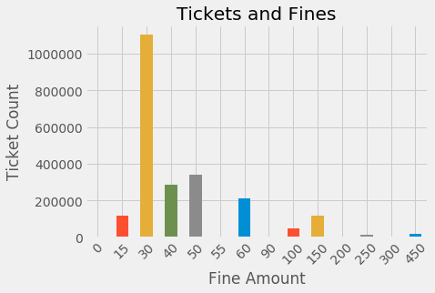

```python
plt.style.use('fivethirtyeight')
fines.plot.bar()
plt.xlabel('Fine Amount')
plt.xticks(rotation=45)
plt.ylabel('Ticket Count')
plt.title('Tickets and Fines')
```

```python
tickets['set_fine_amount'].value_counts(normalize=True) * 100
```

```
30     48.819720
50     14.987974
40     12.703919
60      9.368753
150     5.306416
15      5.296082
100     2.056404
450     0.711517
250     0.651377
90      0.040803
300     0.039073
0       0.009979
55      0.007850
200     0.000133
Name: set_fine_amount, dtype: float64
```

```python
ticket_total = fines * fines.index
```

```python
ticket_total.sum()
```

```
109675985.0
```

Total ticket fines are worth **$109,675,985** in revenue. Tickets are challenged in court and they can reduced or dismissed entirely. Unfortunately that data wasn't available. However we can look at the potential amount of revenue parking tickets bring in for the city.

According to the city of Toronto's Revenue Fact [Sheet](https://www.toronto.ca/city-government/budget-finances/city-finance/long-term-financial-plan/city-revenue-fact-sheet/) parking tickets are worth quite a bit of money when compared to additional revenue options that the city can implement. The options highlighted in grey can't be implemented easily.

[figure not shown]

## Deeper Exploration of Tickets

Now that we have some general information about parking fines we can explore what people are being fined for. We know the most common fine is $30 and that the number of fines is more than 1M.

We can explore the infractions and break it down to see what parking rules drivers are breaking.

```python
infraction_info = tickets[['infraction_code','infraction_description','set_fine_amount']].drop_duplicates(subset='infraction_code').sort_values('infraction_code')
infraction_info
```

|  | infraction_code | infraction_description | set_fine_amount |
| --- | --- | --- | --- |
| 1629565 | 0 | PARK ON PRIVATE PROPERTY | 30 |
| 3325 | 1 | PARK FAIL TO DEPOSIT FEE METER | 30 |
| 777 | 2 | PARK - LONGER THAN 3 HOURS | 15 |
| 5 | 3 | PARK ON PRIVATE PROPERTY | 30 |
| 889 | 4 | PARK ON MUNICIPAL PROPERTY | 30 |
| 39 | 5 | PARK-SIGNED HWY-PROHIBIT DY/TM | 40 |
| 538 | 6 | PARK-SIGNED HWY-EXC PERMT TIME | 40 |
| 43632 | 7 | PARK/LEAVE-FIRE ROUTE | 0 |
| 81 | 8 | STAND VEH.-PROHIBIT TIME/DAY | 60 |
| 22 | 9 | STOP-SIGNED HWY-PROHIBIT TM/DY | 60 |
| 74447 | 10 | PARK UNAUTH VEH IN HDCPD SPACE | 0 |
| 1172 | 11 | PARK/STOP RGHT WHLS > 30CM CRB | 15 |
| 2628 | 12 | PARK VEHICLE - FOR SALE | 15 |
| 104261 | 13 | PARK VEH.-WASH/GREASE/REPAIR | 15 |
| 26 | 14 | PARK-OBSTRUCT (DRWAY/LANEWAY) | 40 |
| 107 | 15 | PARK-WITHIN 3M OF FIRE HYDRANT | 100 |
| 128 | 16 | PARK-WITHIN 9M INTERSECT ROAD | 40 |
| 27148 | 17 | PARK-SIGNED HWY-15M INTERSECTN | 40 |
| 45560 | 18 | PARK-30.5M SIGNALIZED INTERSCT | 40 |
| 941418 | 19 | PARK-FRONT OF BLDG ENTRY/EXIT | 40 |
| 77490 | 20 | PARK-7.5M FIRE HALL SAME SIDE | 40 |
| 44733 | 21 | PARK-30.5M FIRE HALL OPP SIDE | 40 |
| 772253 | 22 | PARK-15M FAR SIDE OF CROSSWALK | 40 |
| 529040 | 23 | PARK-30.5M APPROACH TO CRSSWLK | 40 |
| 1352226 | 25 | STAND SIGNED TAXICAB STAND | 0 |
| 2162863 | 26 | PARK - ON BOULEVARD | 0 |
| 271 | 28 | PARK-N.YORK 2AM-6AM DEC1-MAR31 | 40 |
| 0 | 29 | PARK PROHIBITED TIME NO PERMIT | 30 |
| 539 | 30 | STOP-(ON/OVER) (SIDEWK/FTPATH) | 60 |
| 117 | 31 | STOP-ROAD SIDE-STOP/PARK VEH. | 60 |
| ... | ... | ... | ... |
| 45373 | 372 | PARK BUS-SIGNED HWY-PROH DY/TM | 300 |
| 208 | 373 | STOP BUS-SIGNED HWY-PROH DY/TM | 300 |
| 6806 | 374 | STND BUS-SIGNED HWY-PROH DY/TM | 300 |
| 9634 | 383 | STOP NON-BICYCLE IN CYCLE TRCK | 150 |
| 1185 | 384 | STOP VEH OTR THN BCYCL-BYCL LN | 150 |
| 417761 | 385 | PARK PRO VEH ON FOOTPATH | 60 |
| 6906 | 386 | PARK PRO VEH ON PEDESTRIAN WAY | 60 |
| 9026 | 387 | PARK PRO VEH ON BICYCLE PATH | 60 |
| 16375 | 401 | PARK-SIGNED HWY-RUSH HOUR | 150 |
| 13422 | 402 | STAND VEH.-SIGNED HWY-RUSH HR | 150 |
| 10393 | 403 | STOP-SIGNED HIGHWAY-RUSH HOUR | 150 |
| 6942 | 404 | STOP-9 M PEDESTRIAN X BEYOND | 60 |
| 6943 | 405 | STOP-15M PEDESTRIAN X APPROACH | 60 |
| 4 | 406 | PARK-VEH. W/O VALID ONT PLATE | 40 |
| 693 | 407 | PARK-W/O VALID NON-ONT PLATE | 40 |
| 23900 | 408 | PARK-15M MAILBOX SAME SIDE | 40 |
| 143708 | 409 | STOP-WITHIN 9M OF SCHOOL CROSS | 60 |
| 71875 | 410 | PARK/STAND CAR-SHARE VEH.-PERM | 60 |
| 69980 | 413 | PARK E-VEH. IN EV SP EXCESS TM | 60 |
| 1151 | 414 | PARK VEH.-COMMERCIAL LOAD ZONE | 40 |
| 1952 | 415 | PARK COMMERC LOAD ZONE NOT LDG | 40 |
| 123480 | 416 | STAND VEH.-PSGR LD ZN DAY TIME | 60 |
| 21028 | 417 | STAND VEH.-PSGR LD ZN LD/UNLD | 60 |
| 17533 | 418 | PARK TAXI FOR HIRE-UNAUTH LOC | 40 |
| 1127 | 419 | STAND NON-TAXI IN SIGNED STAND | 60 |
| 10256 | 420 | STAND TAXI-SIGNED STD-NOT HIRE | 60 |
| 14265 | 423 | STOP VEH.RESRVD/DESIG LN TM/DY | 60 |
| 1173813 | 430 | PARK-FAIL TO ACTIVATE METER | 30 |
| 632077 | 432 | PARK MOTORCYCLE-METER-GT 60DEG | 30 |
| 324090 | 434 | PARK IN ELECTRIC VEHICLE SPACE | 60 |

181 rows × 3 columns

```python
tickets['infraction_code'].value_counts()
```

```
5      401636
3      367638
29     339145
210    213327
207    131511
2      116498
9      110457
8       76414
403     74267
406     68271
6       64334
15      35490
192     26024
28      25909
312     21172
```

[output cut: 47 more lines]

Let's filter for tickets with a fine of $30.

```python
fine_30 = tickets[tickets['set_fine_amount'] == 30]
```

```python
fine_30['infraction_code'].value_counts()
```

```
3      367624
29     339145
210    213327
207    131511
312     21172
4        6565
336      5391
48       4885
49       3016
314      2476
1        1948
307      1076
265       991
313       522
11        445
```

[output cut: 29 more lines]

```python
fine_types = fine_30.drop_duplicates(subset='infraction_code')
```

```python
fine_types['infraction_code'].count()
```

```
43
```

There are 43 different infractions with a set fine of $30.

```python
fine_types[['infraction_code', 'infraction_description','set_fine_amount']].sort_values('infraction_code')
```

|  | infraction_code | infraction_description | set_fine_amount |
| --- | --- | --- | --- |
| 1629565 | 0 | PARK ON PRIVATE PROPERTY | 30 |
| 3325 | 1 | PARK FAIL TO DEPOSIT FEE METER | 30 |
| 5 | 3 | PARK ON PRIVATE PROPERTY | 30 |
| 889 | 4 | PARK ON MUNICIPAL PROPERTY | 30 |
| 547699 | 11 | PARK/STOP RGHT WHLS > 30CM CRB | 30 |
| 0 | 29 | PARK PROHIBITED TIME NO PERMIT | 30 |
| 30251 | 38 | PARK OTHER THAN METERED SPACE | 30 |
| 877790 | 39 | PARK MTRD EXCEEDS MAXIMUM TIME | 30 |
| 1507382 | 40 | PARAL PRK-MTRD-FR WHLS NO OPP | 30 |
| 1640097 | 41 | PARALLEL PARK-METERED SPACE-RE | 30 |
| 1415452 | 43 | PARALLEL PARK-METERED SPACE-FR | 30 |
| 907370 | 45 | ANGLE PARK-METERED SPACE-FRONT | 30 |
| 543737 | 48 | FAIL TO PARK/STOP PARALL. CURB | 30 |
| 543901 | 49 | FAIL TO PARK/STOP PARALL. RGHT | 30 |
| 577560 | 50 | FAIL PARK/STP NEAR RIGHT LIMIT | 30 |
| 577078 | 51 | FAIL ANGLE PARK/STOP AT 45 DEG | 30 |
| 807083 | 52 | FAIL TO (PARK/STOP) ANGLE SPCE | 30 |
| 661319 | 54 | PARK/STOP LEFT WHLS > 30CM LFT | 30 |
| 569084 | 55 | PRK/STP LEFT WHLS CLSE TO LEFT | 30 |
| 561373 | 56 | FAIL PARK/STP LEFT WHLS PARALL | 30 |
| 3018 | 207 | PARK MACHINE-REQD FEE NOT PAID | 30 |
| 702422 | 208 | PARK MACHINE-FAIL TO ACTIVATE | 30 |
| 79041 | 209 | PARK MACHINE-NOT IN PERMITD TM | 30 |
| 3009 | 210 | PARK FAIL TO DISPLAY RECEIPT | 30 |
| 20408 | 211 | PARK OTHER THAN METERED SPACE | 30 |
| 442087 | 265 | PARK VEHICLE ON ROADWAY | 30 |
| 32322 | 266 | PARK VEHICLE PROHIBITED TIME | 30 |
| 977202 | 304 | PARK-FRONT OF VEH NOT OPP MTR | 30 |
| 643332 | 306 | ANGLE PARK-TOO FAR FROM METER | 30 |
| 833 | 307 | PARK VEHICLE OUTSIDE OF SPACE | 30 |
| 580495 | 308 | PARK - 2 SPACES - NO FEE | 30 |
| 883789 | 309 | PARK-2 SPACES-NO FEE-MTR/MACH | 30 |
| 22666 | 311 | PARK-FEE NOT PD FOR TIME USED | 30 |
| 886 | 312 | PARKING MACH-NOT USED/NO FEE | 30 |
| 539598 | 313 | PARK-FAIL TO ACTIVATE MACHINE | 30 |
| 885 | 314 | PARK - NOT WITHIN PERIOD | 30 |
| 28941 | 315 | PARK-ISSUED CARD NOT DISPLAYED | 30 |
| 33336 | 317 | PARK/LEAVE CONTRARY TO SIGN | 30 |
| 316426 | 318 | PARK/LEAVE UNPD PARKING INV | 30 |
| 33619 | 335 | PARK MORE THAN 7DAYS NO PERMIT | 30 |
| 459 | 336 | PARK-FAIL TO DISPLAY PERMIT | 30 |
| 1173813 | 430 | PARK-FAIL TO ACTIVATE METER | 30 |
| 632077 | 432 | PARK MOTORCYCLE-METER-GT 60DEG | 30 |

Let's look at the top 10 infractions with a fine of $30.

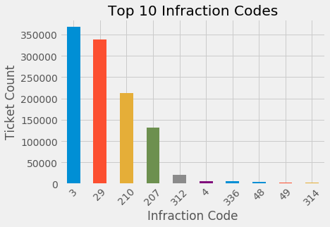

```python
top_10 = fine_30['infraction_code'].value_counts()[:10]
top_10 = top_10.sort_values(ascending=False)
#plt.style.use('ggplot')
top_10.plot.bar()
plt.xlabel('Infraction Code')
plt.xticks(rotation=45)
plt.ylabel('Ticket Count')
plt.title('Top 10 Infraction Codes')
plt.show()
```

## Times that Tickets were Given

We can also look a times that vehicles were ticketed.

```python
times = tickets['time_of_infraction'].value_counts()
times = times.sort_index()
```

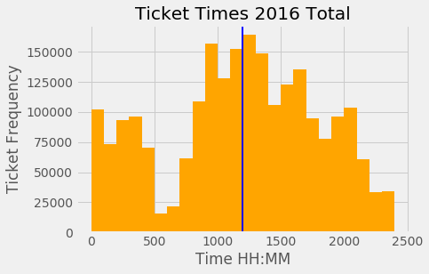

```python
fig, ax = plt.subplots()
ax.hist(tickets['time_of_infraction'], range=(0,2400), bins=24, color='orange')

plt.xlabel('Time HH:MM')
plt.ylabel('Ticket Frequency')
plt.axvline(1200, c='blue', label='Noon', linewidth=2)
plt.title('Ticket Times 2016 Total')
plt.show()
```